# Food Inspection: Modeling Risk Assignment using Ordinal Logistic Regression

### III. MODEL TESTING (ASSESSING MODEL PERFORMANCE)

Now that we know our model passes OLR model assumptions, we can conduct model testing using a 60-40 train-test split.

We already filtered features that were too small, but still need to be careful because our data is imbalanced. We will test a resampling method after the data is split into training and test sets.

Reference Source: Shirin’s plygRound. Dealing with unbalanced data in machine learning, 01 April 2017, r-bloggers.com/2017/04/dealing-with-unbalanced-data-in-machine-learning/

```r
#train-test split on selected features (dta_mini dataset)
set.seed(100)
samplesize = 0.60*nrow(dta_mini)
index = sample(seq_len(nrow(dta_mini)), size = samplesize)

#Creating training and test set
datatrain = dta_mini[index,] #1568 inspections
datatest = dta_mini[-index,] #1046 inspections

#inspection train and test sets
summary(datatrain)
```

```
##    Risk      Inspection.Date HandContamination Contamination FoodTemperature
##  Low :   3   Fall  :362      Pass:1366         Pass:1482     Pass:1461
##  Med : 257   Winter:533      Hit : 202         Hit :  86     Hit : 107
##  High:1308   Spring:359
##              Summer:314
##  FoodIdentification FoodContamination ProperUtensils Equipment
##  Pass:1385          Pass:1246         Pass:1419      Pass:826
##  Hit : 183          Hit : 322         Hit : 149      Hit :742
##
##
##  PhysicalFacilities EmployeeTraining
##  Pass: 342          Pass:1366
##  Hit :1226          Hit : 202
##
##
```

```r
summary(datatest)
```

```
##    Risk     Inspection.Date HandContamination Contamination FoodTemperature
##  Low :  2   Fall  :264      Pass:926          Pass:989      Pass:993
##  Med :181   Winter:374      Hit :120          Hit : 57      Hit : 53
##  High:863   Spring:215
##             Summer:193
##  FoodIdentification FoodContamination ProperUtensils Equipment
##  Pass:917           Pass:814          Pass:960       Pass:562
##  Hit :129           Hit :232          Hit : 86       Hit :484
##
##
##  PhysicalFacilities EmployeeTraining
##  Pass:211           Pass:890
##  Hit :835           Hit :156
##
##
```

Now we can create a model using train data and confirm it still passes the multi-colinearity and proportional odds assumptions.

```r
#build model from train data
#Inspection.DateFall falls off and is absorbed into the intercept again, but that is acceptable for the scope of this analysis. We are more interested in the impact of the health code inspection features.
m_mini_train <- polr(Risk ~., data = datatrain, Hess = T)
#testing multicolinearity, passes (no values > 5)
numRisk_train <- as.numeric(datatrain$Risk)
VIFfit_train <- lm(scale(numRisk_train) ~ ., data = datatrain)
VIF(VIFfit_train)
```

```
##                        GVIF Df GVIF^(1/(2*Df))
## Risk               1.044043  2        1.010833
## Inspection.Date    1.056184  3        1.009152
## HandContamination  1.015802  1        1.007870
## Contamination      1.008324  1        1.004153
## FoodTemperature    1.019004  1        1.009457
## FoodIdentification 1.030913  1        1.015339
## FoodContamination  1.031191  1        1.015476
## ProperUtensils     1.037689  1        1.018670
## Equipment          1.013986  1        1.006969
## PhysicalFacilities 1.030416  1        1.015094
## EmployeeTraining   1.024559  1        1.012205
```

```r
#testing proportional odds assumption, passes (no probability < 0.05 or 0.01)
brant(m_mini_train)
```

```
## ----------------------------------------------------
## Test for     X2  df  probability
## ----------------------------------------------------
## Omnibus          2.15    12  1
## Inspection.DateWinter    0   1   1
## Inspection.DateSpring    0   1   1
## Inspection.DateSummer    0.99    1   0.32
## HandContamination.L  0   1   1
## Contamination.L  0   1   1
## FoodTemperature.L    0   1   1
## FoodIdentification.L 0   1   1
## FoodContamination.L  0.61    1   0.44
## ProperUtensils.L 0   1   1
## Equipment.L      0.46    1   0.5
## PhysicalFacilities.L 0   1   1
## EmployeeTraining.L   0   1   1
## ----------------------------------------------------
##
## H0: Parallel Regression Assumption holds
```

```r
poTest(m_mini_train)
```

```
##
## Tests for Proportional Odds
## polr(formula = Risk ~ ., data = datatrain, Hess = T)
##
##                         b[polr]   b[>Low]   b[>Med] Chisquare df Pr(>Chisq)
## Overall                                                  2.15 12       1.00
## Inspection.DateWinter  3.30e-01  1.89e+01  3.23e-01      0.00  1       1.00
## Inspection.DateSpring -4.13e-01  1.92e+01 -4.23e-01      0.00  1       1.00
## Inspection.DateSummer -5.96e-01  6.13e-01 -6.00e-01      0.99  1       0.32
## HandContamination.L    2.34e-01  1.24e+01  2.33e-01      0.00  1       1.00
## Contamination.L        2.37e-01  1.29e+01  2.34e-01      0.00  1       1.00
## FoodTemperature.L     -4.70e-01  1.21e+01 -4.74e-01      0.00  1       1.00
## FoodIdentification.L   1.77e-01  1.25e+01  1.75e-01      0.00  1       1.00
## FoodContamination.L    1.60e-01 -5.19e-01  1.62e-01      0.61  1       0.44
## ProperUtensils.L       6.30e-01  1.27e+01  6.29e-01      0.00  1       1.00
## Equipment.L            8.17e-02 -5.12e-01  8.19e-02      0.46  1       0.50
## PhysicalFacilities.L   2.16e-02 -1.27e+01  2.36e-02      0.00  1       1.00
## EmployeeTraining.L     6.06e-01  1.25e+01  6.05e-01      0.00  1       1.00
```

With a training model built, we can examine the model performance within the training set. Examining the frequency table, this model has an 83.4% accuracy.

```r
#generating prediction using model built from train data set against the true Risk response recorded in the train dataset
pred1 <- predict(m_mini_train, datatrain)

#view frequency table
table(datatrain$Risk, pred1)
```

```
##       pred1
##         Low  Med High
##   Low     0    0    3
##   Med     0    0  257
##   High    0    0 1308
```

```r
#model test accuracy
sum(diag(table(datatrain$Risk, pred1)  ))/sum(table(datatrain$Risk, pred1)  )
```

```
## [1] 0.8341837
```

Testing the model performance against the test set, the model has an 82% accuracy.

```r
#generating prediction using model built from train set and the test set
pred_test <- predict(m_mini_train, datatest)

#view frequency table
table(datatest$Risk, pred_test)
```

```
##       pred_test
##        Low Med High
##   Low    0   0    2
##   Med    0   0  181
##   High   0   0  863
```

```r
#model test accuracy
sum(diag(table(datatest$Risk, pred_test)))/sum(table(datatest$Risk, pred_test))
```

```
## [1] 0.8250478
```

Testing the model against the full dta_mini data set, the model has an 83% accuracy

```r
#generating prediction using model built from train set and the full dta_mini data set
pred_dta_mini <- predict(m_mini_train, dta_mini)

#view frequency table
table(dta_mini$Risk, pred_dta_mini)
```

```
##       pred_dta_mini
##         Low  Med High
##   Low     0    0    5
##   Med     0    0  438
##   High    0    0 2171
```

```r
#model test accuracy
sum(diag(table(dta_mini$Risk, pred_dta_mini)))/sum(table(dta_mini$Risk, pred_dta_mini))
```

```
## [1] 0.8305279
```

While an 82% accuracy is relatively high, we can see the model is only predicting “High” because of the underlying imbalance in the dataset. While we are building this model to explore what features affected ordinal “Risk” assignment - not to predict future “Risk” assignments with greater accuracy – we can still examine the effect of resampling methods on the model performance.

In the code below, we examine random oversampling where duplicates are randomly selected from the minority class (any Risk factor other than “High”). The overall model accuracy actually drops so our OLR model works best by just predicting “High” Risk factors for all inspections; this is because “Med” and “Low” assignments are less frequent.

Given the drop in accuracy with resampling, we will continue to use our “m_mini” model in upcoming analysis. The “m_mini” OLR model had an 82% accuracy compared to the oversampled model which had a 49% accuracy.

```r
#This function performs a random over-sampling strategy for imbalanced multiclass problems, creating a new dataset sample
new.dat <- RandOverClassif(Risk ~ ., datatrain, "balance")

#create new model from new data set
m_resample <- polr(Risk ~ ., new.dat)
#creating predictions based on test set
random.oversample.pred <- predict(m_resample, datatest, type = "class")

#recall the original confusion matrix using the dta_mini_train model and test set
table(datatest$Risk, pred_test)
```

```
##       pred_test
##        Low Med High
##   Low    0   0    2
##   Med    0   0  181
##   High   0   0  863
```

```r
#confusion matrix after random oversampling
oversample.table = table(datatest$Risk, random.oversample.pred)
oversample.table
```

```
##       random.oversample.pred
##        Low Med High
##   Low    1   1    0
##   Med   58  56   67
##   High 181 228  454
```

```r
#viewing accuracy and confusion matrix summary after random oversampling
sum(diag(oversample.table))/sum(oversample.table)
```

```
## [1] 0.4885277
```

```r
confusionMatrix(oversample.table)
```

```
## Confusion Matrix and Statistics
##
##       random.oversample.pred
##        Low Med High
##   Low    1   1    0
##   Med   58  56   67
##   High 181 228  454
##
## Overall Statistics
##
##                Accuracy : 0.4885
##                  95% CI : (0.4578, 0.5193)
##     No Information Rate : 0.4981
##     P-Value [Acc > NIR] : 0.7419
##
##                   Kappa : 0.0554
##
##  Mcnemar's Test P-Value : <2e-16
##
## Statistics by Class:
##
##                      Class: Low Class: Med Class: High
## Sensitivity            0.004167    0.19649      0.8714
## Specificity            0.998759    0.83574      0.2210
## Pos Pred Value         0.500000    0.30939      0.5261
## Neg Pred Value         0.771073    0.73526      0.6339
## Prevalence             0.229446    0.27247      0.4981
## Detection Rate         0.000956    0.05354      0.4340
## Detection Prevalence   0.001912    0.17304      0.8250
## Balanced Accuracy      0.501463    0.51612      0.5462
```

### IV. MODEL INTERPRETATION AND RESULTS

One way to interpret the OLR model is by examining the p-values. Calculating p-values for each parameter from the m_mini model, we find the all features except Contamination, FoodContamination, Equipment, and PhysicalFacilities are significant at the 0.05 significance level.

And we can note the following features are significant at the 0.01 level:  
- Inspection.DateSpring  
- Inspection.DateSummer  
- FoodTemperature  
- ProperUtensils  
- EmployeeTraining

```r
# store the coefficient table
ctable <- round(coef(summary(m_mini)), 4)

# calculate and store p-values
p <- pnorm(abs(ctable[, "t value"]), lower.tail = F) * 2

# combine coefficient table and p-values table
(ctable <- cbind(ctable, "p value" = round(p, 4)))
```

```
##                         Value Std. Error  t value p value
## Inspection.DateWinter  0.3848     0.1564   2.4602  0.0139
## Inspection.DateSpring -0.4091     0.1531  -2.6727  0.0075
## Inspection.DateSummer -0.6108     0.1544  -3.9567  0.0001
## HandContamination.L    0.2737     0.1298   2.1084  0.0350
## Contamination.L        0.2094     0.1788   1.1712  0.2415
## FoodTemperature.L     -0.4249     0.1403  -3.0283  0.0025
## FoodIdentification.L   0.2873     0.1319   2.1787  0.0294
## FoodContamination.L    0.1026     0.0957   1.0728  0.2834
## ProperUtensils.L       0.5263     0.1666   3.1593  0.0016
## Equipment.L            0.1067     0.0763   1.3978  0.1622
## PhysicalFacilities.L   0.0623     0.0953   0.6542  0.5130
## EmployeeTraining.L     0.7464     0.1492   5.0030  0.0000
## Low|Med               -7.3898     0.5110 -14.4608  0.0000
## Med|High              -2.6670     0.2511 -10.6206  0.0000
```

The coefficients of the model can be difficult to interpret because they are on a log scale. We can convert the coefficients into odds ratios and calculate 95% confidence intervals for easier interpretation.

Reference Source: UCLA: Stiatistical Consulting Group. Ordinal Logistic Regression | R Data Analysis Examples, stats.idre.ucla.edu/r/dae/ordinal-logistic-regression/

```r
# computed confidence intervals (CIs_), rounded to 4 digits
ci <- round(confint(m_mini), 4)
# log odd coefficients
or <- round(coef(m_mini), 4)

# convert coefficients into odds ratio, combine with CIs
#note: if CI doesn't cross 0 parameter, the param is statistically significant and we can see the four parameters that do cross are the same as the parameters found not to be significant in at the 0.05 level in the ctable above (Contamination, FoodContamination, Equipment, and PhysicalFacilities)
round(exp(cbind(OR = or, ci)), 4)
```

```
##                           OR  2.5 % 97.5 %
## Inspection.DateWinter 1.4693 1.0806 1.9967
## Inspection.DateSpring 0.6642 0.4911 0.8954
## Inspection.DateSummer 0.5429 0.4002 0.7334
## HandContamination.L   1.3148 1.0276 1.7116
## Contamination.L       1.2329 0.8821 1.7843
## FoodTemperature.L     0.6538 0.4994 0.8667
## FoodIdentification.L  1.3328 1.0377 1.7425
## FoodContamination.L   1.1080 0.9214 1.3411
## ProperUtensils.L      1.6927 1.2400 2.3898
## Equipment.L           1.1126 0.9583 1.2927
## PhysicalFacilities.L  1.0643 0.8807 1.2801
## EmployeeTraining.L    2.1094 1.5957 2.8705
```

**Interpretation of the odds ratio:**

- For restaurants with Inspection Dates in Winter, the odds of getting a higher level risk inspection rating (ex. Med or High vs Low) is 1.46 times that of restaurants who get Inspections in other seasons, holding constant all other variables.
- For restaurants with Inspection Dates in Spring, the odds of getting a higher level risk inspection rating (ex. Med or High vs Low) is 0.66 times that of restaurants who get Inspections in other seasons, holding constant all other variables.
- For restaurants with Inspection Dates in Summer, the odds of getting a higher level risk inspection rating (ex. Med or High vs Low) is 0.54 times that of restaurants who get Inspections in other seasons, holding constant all other variables.
- For restaurants with Hand Contamination violations, the odds of getting a higher risk level inspection rating (ex. Med or High Risk versus Low) is 1.31 times that of restaurants who did not get Hand Contamination violations, holding constant all other variables.
- For restaurants with Contamination violations, the odds of getting a higher risk level inspection rating (ex. Med or High Risk versus Low) is 1.23 times that of restaurants who did not get Contamination violations, holding constant all other variables.
- For restaurants with Food Temperature violations, the odds of getting a higher risk level inspection rating (ex. Med or High Risk versus Low) is 0.65 times that of restaurants who did not get Food Temperature violations, holding constant all other variables.
- For restaurants with Food Identification violations, the odds of getting a higher risk level inspection rating (ex. Med or High Risk versus Low) is 1.33 times that of restaurants who did not get Food Identification violations, holding constant all other variables.
- For restaurants with Food Contamination violations, the odds of getting a higher risk level inspection rating (ex. Med or High Risk versus Low) is 1.11 times that of restaurants who did not get Food Contamination violations, holding constant all other variables.
- For restaurants with Proper Utensils violations, the odds of getting a higher risk level inspection rating (ex. Med or High Risk versus Low) is 1.69 times that of restaurants who did not get Proper Utensils violations, holding constant all other variables.
- For restaurants with Equipment violations, the odds of getting a higher risk level inspection rating (ex. Med or High Risk versus Low) is 1.11 times that of restaurants who did not get Equipment violations, holding constant all other variables.
- For restaurants with Physical Facilities violations, the odds of getting a higher risk level inspection rating (ex. Med or High Risk versus Low) is 1.06 times that of restaurants who did not get Physical Facilities violations, holding constant all other variables.
- For restaurants with Employee Training violations, the odds of getting a higher risk level inspection rating (ex. Med or High Risk versus Low) is 2.11 times that of restaurants who did not get Employee violations, holding constant all other variables.

**Key takeaways:**

- Inspections in winter and violations in hand contamination, food identification, proper utensils, and employee training increased the odds of higher risk assignment.
- Inspections in the Spring or Summer reduced the odds of higher risk assignment.

**Key takeaway interpretation:**

- Inspection date impacts the odds of risk assignment. Odds of risk assignment might increase in winter because restaurants are more likely to lose power (impacting the facility’s ability to maintain health code standards). Restaurants may also be more prepared for inspections in spring and summer as those are traditional busy seasons.
- The log odds of food temperature violations is also less than zero, but this might be tied to less frequent power outages outside of winter months (freezers maintain temperatures more reliably).

### v. ADDITIONAL INSIGHT

With a model established, we can examine the effects of an independent variable on the response assignment probabilities. It is also possible to look at joint effect of multiple independent variable.

Plotting effects using the library “effects” shows the change in probability of risk assignment based on individual feature levels (“pass” or “hit”; “Summer”, “Spring”, “Winter”, “Fall”). Examining probability changes in this case is more intuitive than examining coefficients.

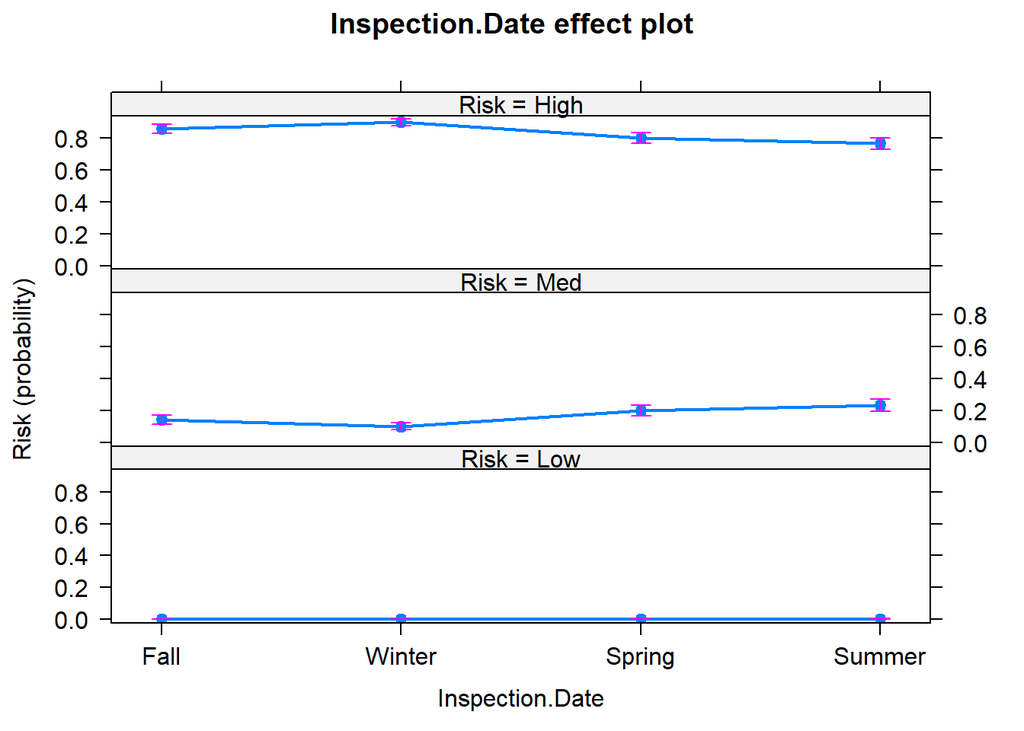

```r
#plotting individual effects
plot(Effect(focal.predictors = "Inspection.Date",m_mini))
```

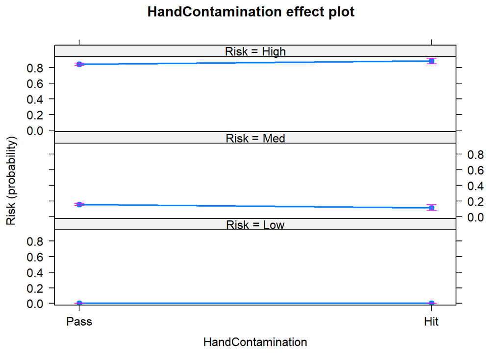

```r
plot(Effect(focal.predictors = "HandContamination",m_mini))
```

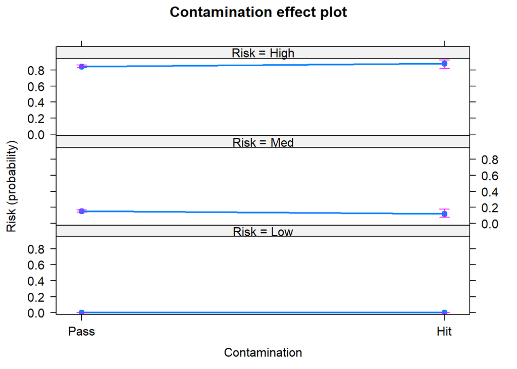

```r
plot(Effect(focal.predictors = "Contamination",m_mini))
```

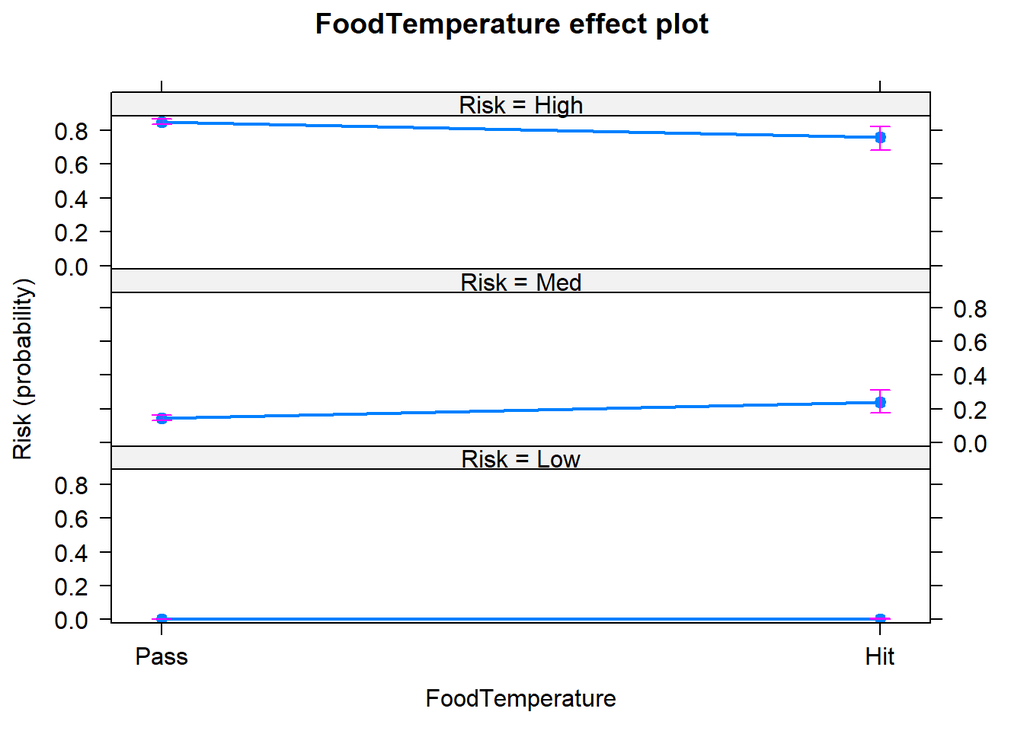

```r
plot(Effect(focal.predictors = "FoodTemperature",m_mini))
```

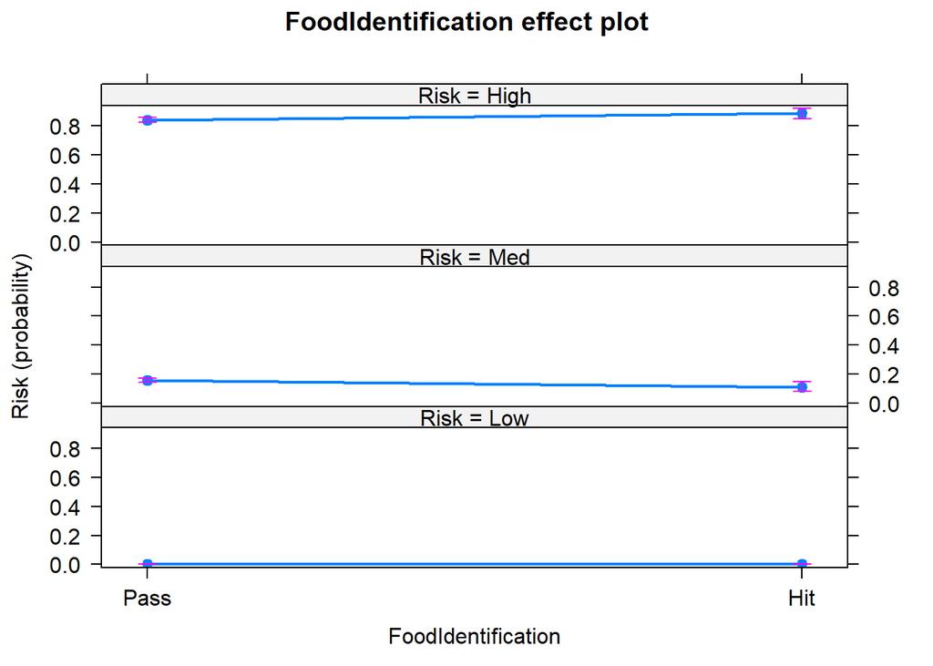

```r
plot(Effect(focal.predictors = "FoodIdentification",m_mini))
```

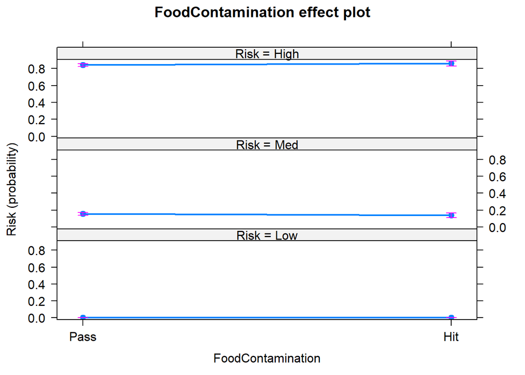

```r
plot(Effect(focal.predictors = "FoodContamination",m_mini))
```

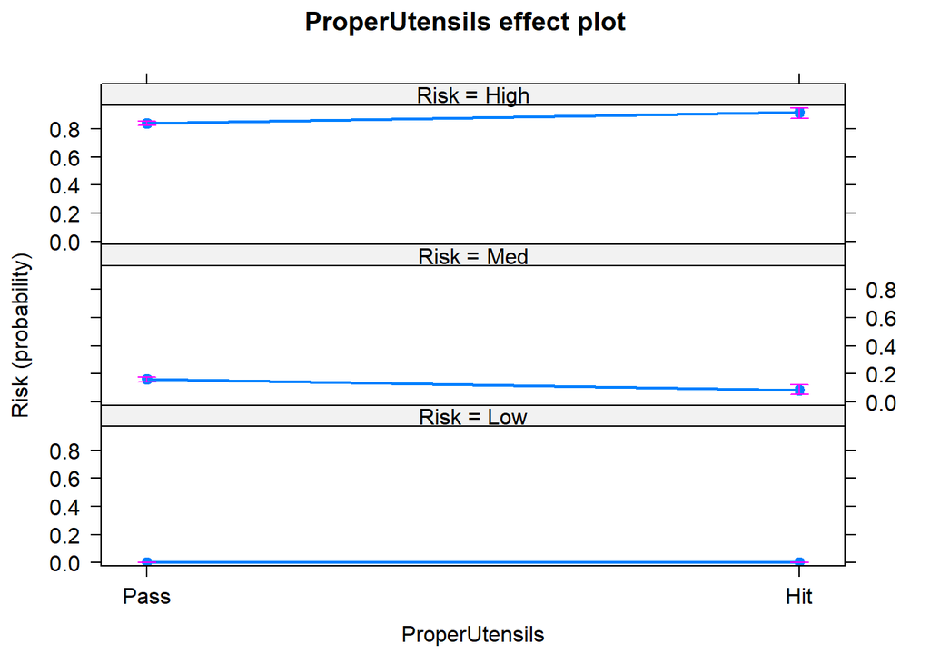

```r
plot(Effect(focal.predictors = "ProperUtensils",m_mini))
```

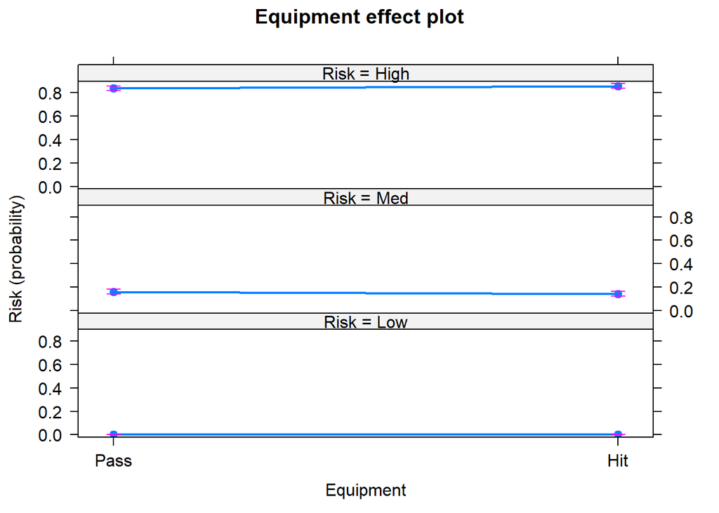

```r
plot(Effect(focal.predictors = "Equipment",m_mini))
```

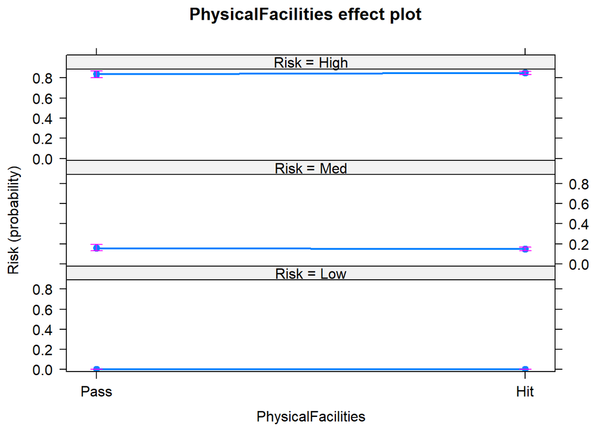

```r
plot(Effect(focal.predictors = "PhysicalFacilities",m_mini))
```

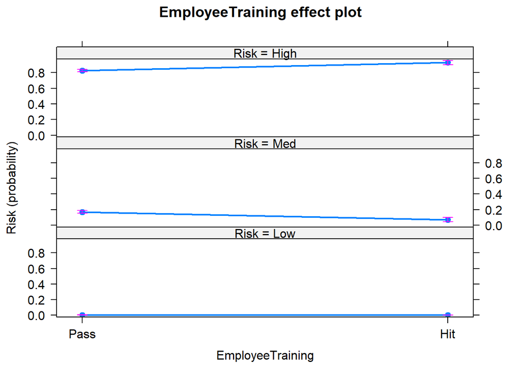

```r
plot(Effect(focal.predictors = "EmployeeTraining",m_mini))
```

We can also examine fitting the model using probit or complementary log-log (cloglog) methods. However, the probit and cloglog model coefficients are not in terms of log odds and not interpretable as log odds. Given the residual deviance and AIC values for the probit, cloglog, and logistic (the default OLR model which we used to create our m_mini model) are all very similar, we recommend using the original m_mini (logisitic) model for this analysis.

Reference Source: Analytics Vidhya. How to use Multinomial and Ordinal Logistic Regression in R, 01 February 2016, analyticsvidhya.com/blog/2016/02/multinomial-ordinal-logistic-regression.

```r
#update and refit our model with the probit method
m_mini_probit <- update(m_mini, method = "probit", Hess = TRUE)
summary(m_mini_probit)
```

```
## Call:
## polr(formula = Risk ~ ., data = dta_mini, Hess = TRUE, method = "probit")
##
## Coefficients:
##                          Value Std. Error t value
## Inspection.DateWinter  0.22068    0.08402  2.6264
## Inspection.DateSpring -0.21783    0.08567 -2.5428
## Inspection.DateSummer -0.34623    0.08678 -3.9896
## HandContamination.L    0.15593    0.06992  2.2303
## Contamination.L        0.13168    0.09847  1.3373
## FoodTemperature.L     -0.24703    0.08062 -3.0640
## FoodIdentification.L   0.17114    0.07145  2.3953
## FoodContamination.L    0.05317    0.05267  1.0094
## ProperUtensils.L       0.27844    0.08580  3.2454
## Equipment.L            0.05913    0.04231  1.3976
## PhysicalFacilities.L   0.03757    0.05254  0.7151
## EmployeeTraining.L     0.39905    0.07512  5.3125
##
## Intercepts:
##          Value    Std. Error t value
## Low|Med   -3.5698   0.2000   -17.8525
## Med|High  -1.5330   0.1350   -11.3591
##
## Residual Deviance: 2309.677
## AIC: 2337.677
```

```r
#compare models
anova(m_mini, m_mini_probit)
```

```
## Likelihood ratio tests of ordinal regression models
##
## Response: Risk
##                                                                                                                                                                                 Model
## 1 Inspection.Date + HandContamination + Contamination + FoodTemperature + FoodIdentification + FoodContamination + ProperUtensils + Equipment + PhysicalFacilities + EmployeeTraining
## 2 Inspection.Date + HandContamination + Contamination + FoodTemperature + FoodIdentification + FoodContamination + ProperUtensils + Equipment + PhysicalFacilities + EmployeeTraining
##   Resid. df Resid. Dev   Test    Df LR stat. Pr(Chi)
## 1      2600   2312.469
## 2      2600   2309.677 1 vs 2     0  2.79238       0
```

```r
#update and refit model using complementary log log
m_mini_clog <- update(m_mini, method = "cloglog", Hess = TRUE)
summary(m_mini_clog)
```

```
## Call:
## polr(formula = Risk ~ ., data = dta_mini, Hess = TRUE, method = "cloglog")
##
## Coefficients:
##                          Value Std. Error t value
## Inspection.DateWinter  0.34916    0.14450  2.4164
## Inspection.DateSpring -0.36937    0.13719 -2.6923
## Inspection.DateSummer -0.53819    0.13715 -3.9241
## HandContamination.L    0.24415    0.11923  2.0478
## Contamination.L        0.18008    0.16256  1.1078
## FoodTemperature.L     -0.36538    0.11912 -3.0674
## FoodIdentification.L   0.25246    0.12093  2.0876
## FoodContamination.L    0.09385    0.08610  1.0899
## ProperUtensils.L       0.48311    0.15621  3.0927
## Equipment.L            0.09177    0.06848  1.3401
## PhysicalFacilities.L   0.04883    0.08528  0.5725
## EmployeeTraining.L     0.68649    0.14129  4.8586
##
## Intercepts:
##          Value    Std. Error t value
## Low|Med   -7.2822   0.5012   -14.5300
## Med|High  -2.6804   0.2293   -11.6912
##
## Residual Deviance: 2313.683
## AIC: 2341.683
```

```r
#compare models
anova(m_mini, m_mini_clog)
```

```
## Likelihood ratio tests of ordinal regression models
##
## Response: Risk
##                                                                                                                                                                                 Model
## 1 Inspection.Date + HandContamination + Contamination + FoodTemperature + FoodIdentification + FoodContamination + ProperUtensils + Equipment + PhysicalFacilities + EmployeeTraining
## 2 Inspection.Date + HandContamination + Contamination + FoodTemperature + FoodIdentification + FoodContamination + ProperUtensils + Equipment + PhysicalFacilities + EmployeeTraining
##   Resid. df Resid. Dev   Test    Df  LR stat. Pr(Chi)
## 1      2600   2312.469
## 2      2600   2313.683 1 vs 2     0 -1.213399       1
```

END